# Cx43 puncta per cell: differential expression analysis

2024-02-19 10:16:25

# Load libraries

```r
library(stringr)
library(MASS)
library(car)
library(AICcmodavg)
library(effectsize)
```

# Define functions

```r
fitCandidateModels <- function(varName){
  candidateModels <- list()
  candidateModels[[1]] <- eval(parse(text=str_c("lm(",varName,"~ group, data=dat)")))
  candidateModels[[2]] <- eval(parse(text=str_c("lm(",varName,"~ group + batch, data=dat)")))
  candidateModels[[3]] <- eval(parse(text=str_c("lm(",varName,"~ group + Age, data=dat)")))
  candidateModels[[4]] <- eval(parse(text=str_c("lm(",varName,"~ group + Gender, data=dat)")))
  candidateModels[[5]] <- eval(parse(text=str_c("lm(",varName,"~ group + batch + Age, data=dat)")))
  candidateModels[[6]] <- eval(parse(text=str_c("lm(",varName,"~ group + batch + Gender, data=dat)")))
  candidateModels[[7]] <- eval(parse(text=str_c("lm(",varName,"~ group + Age + Gender, data=dat)")))
  candidateModels[[8]] <- eval(parse(text=str_c("lm(",varName,"~ group + batch + Age + Gender, data=dat)")))
  return(candidateModels)
}

modelNames <- c("group",
"group+batch",
"group+Age",
"group+Gender",
"group+batch+Age",
"group+batch+Gender",
"group+Age+Gender",
"group+batch+Age+Gender")


processVariable <- function(varName, diag=TRUE){
  cat("\n\n## ", varName,"\n")
  cat("\n\n### Performance of candidate models\n")
  candidateModels <- fitCandidateModels(varName)
  resTab <- aictab(cand.set = candidateModels, modnames = modelNames)
  print(knitr::kable(resTab))

  idxBestModel <- as.numeric(row.names(resTab)[1])
  if(diag){
    cat("\n\n### Diagnostics for best model")
    plot(candidateModels[[idxBestModel]])
  }
  (shapiroResid <- shapiro.test(candidateModels[[idxBestModel]]$residuals))
  return(list(indexBest=idxBestModel, bestModel=candidateModels[[idxBestModel]], shapiroResidP=shapiroResid$p.value))
}
```

# Load data

```r
donors <- read.csv("../data/donor_metadata.csv", row.names=1, na.strings="NA")

puncta <- read.csv("../data/Cx43_puncta_per_cell_BoxCox_transformed.csv", row.names=1)
punctaRaw <- read.csv("../data/Cx43 puncta per cell - Sheet1.csv", row.names=1)
punctaRaw <- punctaRaw[c(18:29, 10:17, 1:9, 30:40),]

group <- c(rep("P", 20),rep("C", 20))
groupColor <- c(rep("red", 20),rep("blue", 20))

batches <- read.csv("../data/Cx43_puncta_batches.csv", row.names=1, stringsAsFactors = TRUE)
batches <- batches[c(18:29, 10:17, 1:9, 30:40),]
row.names(batches)==row.names(puncta)
```

```
##  [1] TRUE TRUE TRUE TRUE TRUE TRUE TRUE TRUE TRUE TRUE TRUE TRUE TRUE TRUE TRUE
## [16] TRUE TRUE TRUE TRUE TRUE TRUE TRUE TRUE TRUE TRUE TRUE TRUE TRUE TRUE TRUE
## [31] TRUE TRUE TRUE TRUE TRUE TRUE TRUE TRUE TRUE TRUE
```

```r
names(batches)==names(puncta)
```

```
## [1] TRUE TRUE TRUE TRUE TRUE TRUE TRUE
```

Create data.frame:

```r
batch <- rep(NA,40)
dat <- data.frame(cbind(group,
                        batch,
                        donors,
                        puncta$Frontal.cortex,
                        puncta$Parietal.cortex,
                        puncta$Insular.cortex,
                        puncta$BG.Putamen,
                        puncta$BG.Globus.P,
                        puncta$BG.Caudate,
                        puncta$Midbrain.SN))

varNames <- names(dat)[21:27] <- c("Frontal.cortex",
                "Parietal.cortex",
                "Insular.cortex",
                "BG.Putamen",
                "BG.Globus.P",
                "BG.Caudate",
                "Midbrain.SN")
```

# Find best model for each variable

```r
bestModels <- vector("list", length(varNames))
for (i in 1:length(varNames)){
  dat$batch<-rep(NA,40)
  dat$batch<-batches[,i]
  bestModels[[i]] <- processVariable(varName=varNames[i],
                                     diag=F)
}
```

## Frontal.cortex

### Performance of candidate models

|  | Modnames | K | AICc | Delta_AICc | ModelLik | AICcWt | LL | Cum.Wt |
| --- | --- | --- | --- | --- | --- | --- | --- | --- |
| 1 | group | 3 | 175.6896 | 0.000000 | 1.0000000 | 0.5242641 | -84.51146 | 0.5242641 |
| 4 | group+Gender | 4 | 177.9929 | 2.303262 | 0.3161207 | 0.1657307 | -84.42500 | 0.6899948 |
| 3 | group+Age | 4 | 178.0398 | 2.350186 | 0.3087903 | 0.1618877 | -84.44846 | 0.8518825 |
| 2 | group+batch | 6 | 179.8608 | 4.171198 | 0.1242327 | 0.0651307 | -82.65767 | 0.9170132 |
| 7 | group+Age+Gender | 5 | 180.4678 | 4.778228 | 0.0917109 | 0.0480807 | -84.35156 | 0.9650939 |
| 5 | group+batch+Age | 7 | 182.5961 | 6.906544 | 0.0316419 | 0.0165887 | -82.54807 | 0.9816827 |
| 6 | group+batch+Gender | 7 | 182.8148 | 7.125202 | 0.0283650 | 0.0148707 | -82.65740 | 0.9965534 |
| 8 | group+batch+Age+Gender | 8 | 185.7388 | 10.049213 | 0.0065742 | 0.0034466 | -82.54682 | 1.0000000 |

## Parietal.cortex

### Performance of candidate models

|  | Modnames | K | AICc | Delta_AICc | ModelLik | AICcWt | LL | Cum.Wt |
| --- | --- | --- | --- | --- | --- | --- | --- | --- |
| 1 | group | 3 | 148.5853 | 0.000000 | 1.0000000 | 0.5410413 | -70.94981 | 0.5410413 |
| 3 | group+Age | 4 | 151.0755 | 2.490156 | 0.2879184 | 0.1557757 | -70.94951 | 0.6968170 |
| 4 | group+Gender | 4 | 151.0759 | 2.490551 | 0.2878616 | 0.1557450 | -70.94971 | 0.8525620 |
| 2 | group+batch | 7 | 152.6560 | 4.070644 | 0.1306384 | 0.0706808 | -67.52154 | 0.9232428 |
| 7 | group+Age+Gender | 5 | 153.7169 | 5.131615 | 0.0768571 | 0.0415829 | -70.94938 | 0.9648257 |
| 6 | group+batch+Gender | 8 | 155.4734 | 6.888103 | 0.0319350 | 0.0172782 | -67.33672 | 0.9821038 |
| 5 | group+batch+Age | 8 | 155.7976 | 7.212219 | 0.0271573 | 0.0146932 | -67.49878 | 0.9967970 |
| 8 | group+batch+Age+Gender | 9 | 158.8442 | 10.258843 | 0.0059200 | 0.0032030 | -67.31864 | 1.0000000 |

## Insular.cortex

### Performance of candidate models

|  | Modnames | K | AICc | Delta_AICc | ModelLik | AICcWt | LL | Cum.Wt |
| --- | --- | --- | --- | --- | --- | --- | --- | --- |
| 2 | group+batch | 7 | 161.7176 | 0.000000 | 1.0000000 | 0.4475932 | -71.99216 | 0.4475932 |
| 5 | group+batch+Age | 8 | 163.3282 | 1.610564 | 0.4469619 | 0.2000571 | -71.18135 | 0.6476503 |
| 6 | group+batch+Gender | 8 | 164.2915 | 2.573811 | 0.2761239 | 0.1235912 | -71.66297 | 0.7712415 |
| 1 | group | 3 | 164.6941 | 2.976428 | 0.2257755 | 0.1010556 | -78.99410 | 0.8722971 |
| 8 | group+batch+Age+Gender | 9 | 166.1955 | 4.477889 | 0.1065709 | 0.0477004 | -70.88348 | 0.9199975 |
| 3 | group+Age | 4 | 166.5299 | 4.812212 | 0.0901657 | 0.0403576 | -78.65887 | 0.9603551 |
| 4 | group+Gender | 4 | 167.1966 | 5.478988 | 0.0646030 | 0.0289159 | -78.99226 | 0.9892710 |
| 7 | group+Age+Gender | 5 | 169.1795 | 7.461866 | 0.0239705 | 0.0107290 | -78.65226 | 1.0000000 |

## BG.Putamen

### Performance of candidate models

|  | Modnames | K | AICc | Delta_AICc | ModelLik | AICcWt | LL | Cum.Wt |
| --- | --- | --- | --- | --- | --- | --- | --- | --- |
| 8 | group+batch+Age+Gender | 9 | 165.3756 | 0.0000000 | 1.0000000 | 0.3244007 | -70.58437 | 0.3244007 |
| 6 | group+batch+Gender | 8 | 166.0058 | 0.6301476 | 0.7297350 | 0.2367266 | -72.60290 | 0.5611273 |
| 5 | group+batch+Age | 8 | 166.1775 | 0.8019016 | 0.6696830 | 0.2172457 | -72.68877 | 0.7783729 |
| 2 | group+batch | 7 | 166.3579 | 0.9822688 | 0.6119318 | 0.1985111 | -74.37251 | 0.9768841 |
| 3 | group+Age | 4 | 172.8251 | 7.4494838 | 0.0241193 | 0.0078243 | -81.82433 | 0.9847084 |
| 7 | group+Age+Gender | 5 | 173.2400 | 7.8643645 | 0.0196009 | 0.0063585 | -80.71091 | 0.9910669 |
| 1 | group | 3 | 173.5905 | 8.2148822 | 0.0164498 | 0.0053363 | -83.45241 | 0.9964032 |
| 4 | group+Gender | 4 | 174.3795 | 9.0038931 | 0.0110874 | 0.0035968 | -82.60153 | 1.0000000 |

## BG.Globus.P

### Performance of candidate models

|  | Modnames | K | AICc | Delta_AICc | ModelLik | AICcWt | LL | Cum.Wt |
| --- | --- | --- | --- | --- | --- | --- | --- | --- |
| 5 | group+batch+Age | 8 | 95.06716 | 0.0000000 | 1.0000000 | 0.4593258 | -36.26085 | 0.4593258 |
| 2 | group+batch | 7 | 95.92153 | 0.8543736 | 0.6523417 | 0.2996373 | -38.52598 | 0.7589631 |
| 8 | group+batch+Age+Gender | 9 | 98.51630 | 3.4491482 | 0.1782489 | 0.0818743 | -35.97244 | 0.8408374 |
| 6 | group+batch+Gender | 8 | 99.28667 | 4.2195154 | 0.1212673 | 0.0557012 | -38.37061 | 0.8965386 |
| 3 | group+Age | 4 | 100.06349 | 4.9963376 | 0.0822355 | 0.0377729 | -45.26252 | 0.9343115 |
| 1 | group | 3 | 100.15297 | 5.0858158 | 0.0786374 | 0.0361202 | -46.63204 | 0.9704317 |
| 7 | group+Age+Gender | 5 | 101.79814 | 6.7309806 | 0.0345451 | 0.0158674 | -44.69907 | 0.9862991 |
| 4 | group+Gender | 4 | 102.09176 | 7.0245993 | 0.0298282 | 0.0137009 | -46.27665 | 1.0000000 |

## BG.Caudate

### Performance of candidate models

|  | Modnames | K | AICc | Delta_AICc | ModelLik | AICcWt | LL | Cum.Wt |
| --- | --- | --- | --- | --- | --- | --- | --- | --- |
| 7 | group+Age+Gender | 5 | 106.0232 | 0.000000 | 1.0000000 | 0.5180070 | -46.70724 | 0.5180070 |
| 3 | group+Age | 4 | 107.5933 | 1.570141 | 0.4560876 | 0.2362566 | -48.96333 | 0.7542636 |
| 1 | group | 3 | 110.0991 | 4.075936 | 0.1302932 | 0.0674928 | -51.56956 | 0.8217563 |
| 5 | group+batch+Age | 8 | 110.1002 | 4.077060 | 0.1302200 | 0.0674549 | -43.45012 | 0.8892112 |
| 4 | group+Gender | 4 | 110.2491 | 4.225936 | 0.1208786 | 0.0626160 | -50.29122 | 0.9518272 |
| 8 | group+batch+Age+Gender | 9 | 111.1401 | 5.116912 | 0.0774242 | 0.0401063 | -41.83320 | 0.9919334 |
| 2 | group+batch | 7 | 114.8518 | 8.828662 | 0.0121026 | 0.0062693 | -47.75925 | 0.9982027 |
| 6 | group+batch+Gender | 8 | 117.3506 | 11.327413 | 0.0034696 | 0.0017973 | -47.07530 | 1.0000000 |

## Midbrain.SN

### Performance of candidate models

|  | Modnames | K | AICc | Delta_AICc | ModelLik | AICcWt | LL | Cum.Wt |
| --- | --- | --- | --- | --- | --- | --- | --- | --- |
| 1 | group | 3 | 116.6347 | 0.000000 | 1.0000000 | 0.5669514 | -54.98403 | 0.5669514 |
| 3 | group+Age | 4 | 119.0968 | 2.462052 | 0.2919928 | 0.1655457 | -54.97696 | 0.7324971 |
| 4 | group+Gender | 4 | 119.1019 | 2.467173 | 0.2912461 | 0.1651224 | -54.97952 | 0.8976195 |
| 7 | group+Age+Gender | 5 | 121.7081 | 5.073333 | 0.0791297 | 0.0448627 | -54.97167 | 0.9424822 |
| 2 | group+batch | 7 | 121.9759 | 5.341157 | 0.0692122 | 0.0392399 | -52.23794 | 0.9817222 |
| 5 | group+batch+Age | 8 | 125.0382 | 8.403502 | 0.0149693 | 0.0084869 | -52.19653 | 0.9902091 |
| 6 | group+batch+Gender | 8 | 125.1086 | 8.473909 | 0.0144515 | 0.0081933 | -52.23173 | 0.9984024 |
| 8 | group+batch+Age+Gender | 9 | 128.3782 | 11.743513 | 0.0028179 | 0.0015976 | -52.18912 | 1.0000000 |

```r
length(bestModels)
```

[1] 7

```r
bmDF <- data.frame(cbind(Variable=varNames, Best.Model=rep(NA,length(bestModels)), ShapiroResidP=rep(NA,length(bestModels))))
for (i in 1:length(bestModels)){
  bmDF$Best.Model[i]<- modelNames[bestModels[[i]]$indexBest]
  bmDF$ShapiroResidP[i] <- bestModels[[i]]$shapiroResidP
}

bmDF$ShapiroResidP <- round(as.numeric(bmDF$ShapiroResidP),3)
names(bmDF) <- c("Variable", "Best Model", "Shapiro-Wilk Test on Model Residuals (p-value)")

cat("\n")
```

```r
print(knitr::kable(bmDF))
```

| Variable | Best Model | Shapiro-Wilk Test on Model Residuals (p-value) |
| --- | --- | --- |
| Frontal.cortex | group | 0.401 |
| Parietal.cortex | group | 0.078 |
| Insular.cortex | group+batch | 0.444 |
| BG.Putamen | group+batch+Age+Gender | 0.485 |
| BG.Globus.P | group+batch+Age | 0.269 |
| BG.Caudate | group+Age+Gender | 0.035 |
| Midbrain.SN | group | 0.952 |

*N.B. Model residuals should follow a normal distribution. Here we see that the residuals of the models for BG.Caudate do not. However, as we’ll see in the next section, we are not claiming that this variable differs in expression between Parkinson’s Disease patients and controls.*

# ANOVA

```r
anovaRawP <- rep(NA,length(bestModels))
epsilonSquared <- rep(NA, length(bestModels))
meanControl <- meanPD <- sdControl <- sdPD <- rep(NA, length(varNames))

for (i in 1:length(bestModels)){
  anovaTab <- Anova(bestModels[[i]]$bestModel, type="II")
  anovaRawP[i] <- anovaTab$`Pr(>F)`[row.names(anovaTab)=="group"]
  epsilonSquared[i] <- epsilon_squared(anovaTab)[[2]][1]
  rawVar <- eval(parse(text=str_c("punctaRaw$",varNames[i])))
  meanControl[i] <- mean(rawVar[group=="C"], na.rm=TRUE)
  sdControl[i] <- sd(rawVar[group=="C"], na.rm=TRUE)
  meanPD[i] <- mean(rawVar[group=="P"], na.rm=TRUE)
  sdPD[i] <- sd(rawVar[group=="P"], na.rm=TRUE)
}
```

```
## For one-way between subjects designs, partial epsilon squared is
##   equivalent to epsilon squared. Returning epsilon squared.
## For one-way between subjects designs, partial epsilon squared is
##   equivalent to epsilon squared. Returning epsilon squared.
## For one-way between subjects designs, partial epsilon squared is
##   equivalent to epsilon squared. Returning epsilon squared.
```

```r
holm <- p.adjust(anovaRawP, method="holm")
bh <- p.adjust(anovaRawP, method="BH")

effectInterpretation <- interpret_epsilon_squared(epsilonSquared)

nControl <- apply(puncta[group=="C",],2,function(x){length(x)-sum(is.na(x))})
nPD <- apply(puncta[group=="P",],2,function(x){length(x)-sum(is.na(x))})

resTab <- data.frame(cbind(varNames, nControl, nPD,
                           format(round(anovaRawP,4), scientific=FALSE),
                           format(round(holm,4), scientific=FALSE),
                           format(round(bh,4), scientific=FALSE),
                           round(epsilonSquared,4), effectInterpretation,
                     meanControl, sdControl, meanPD, sdPD))
names(resTab) <- c("Variable", "Control n", "PD n", "Raw p-value", "Adj. p-value (FWER)", "Adj. p-value (FDR)", "Effect size (epsilon2)", "Effect size (qualitative)",
                   "Mean Control", "SD Control", "Mean PD", "SD PD")
knitr::kable(resTab)
```

|  | Variable | Control n | PD n | Raw p-value | Adj. p-value (FWER) | Adj. p-value (FDR) | Effect size (epsilon2) | Effect size (qualitative) | Mean Control | SD Control | Mean PD | SD PD |
| --- | --- | --- | --- | --- | --- | --- | --- | --- | --- | --- | --- | --- |
| Frontal.cortex | Frontal.cortex | 20 | 20 | 0.0045 | 0.0179 | 0.0078 | 0.1726 | large | 18.75965942457 | 14.4388240750877 | 8.1151350262 | 9.41112596173203 |
| Parietal.cortex | Parietal.cortex | 19 | 20 | 0.0004 | 0.0021 | 0.0010 | 0.2691 | large | 24.9210108710684 | 18.2865900236812 | 7.70121725005 | 7.43463971967359 |
| Insular.cortex | Insular.cortex | 18 | 20 | 0.0000 | 0.0000 | 0.0000 | 0.4784 | large | 28.6692959873944 | 15.7381175045402 | 7.92030470241 | 7.27834709017159 |
| BG.Putamen | BG.Putamen | 19 | 20 | 0.2491 | 0.5208 | 0.2907 | 0.0117 | small | 6.67391949235263 | 15.0042932981058 | 0.8533406946333 | 1.33706327530441 |
| BG.Globus.P | BG.Globus.P | 16 | 15 | 0.0001 | 0.0006 | 0.0004 | 0.452 | large | 6.93480026020625 | 11.3115797721629 | 0.84618472896 | 0.947743228686354 |
| BG.Caudate | BG.Caudate | 15 | 14 | 0.1736 | 0.5208 | 0.2430 | 0.0357 | small | 9.50289365014 | 10.777472162295 | 3.30093743913571 | 4.14074495480128 |
| Midbrain.SN | Midbrain.SN | 20 | 20 | 0.5033 | 0.5208 | 0.5033 | 0 | very small | 16.243370617115 | 28.4367706187038 | 9.391320540075 | 10.0784981000673 |

*Notes*

- p-values are for the difference between the Parkinson’s Disease patients and controls.
- FWER: Family-wise error rate
- FDR: False discovery rate
- Effect size ($\epsilon^2$) is the proportion of the variation in the protein expression variable explained by group membership (control *vs* PD).
- Means and SDs are for raw, rather than Box-Cox transformed data. However, linear modelling and ANOVA used Box-Cox transformed data.

*Field’s (2013) qualitative interpretation of effect size*

## Boxplots

### Frontal.cortex

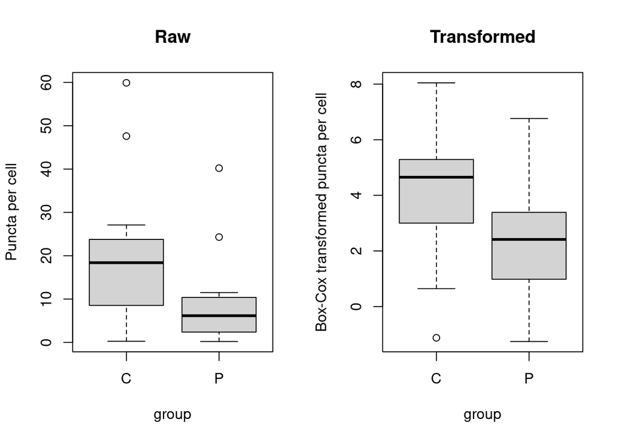

```r
par(mfrow=c(1,2))
boxplot(punctaRaw$Frontal.cortex~group, main="Raw", ylab="Puncta per cell")
boxplot(puncta$Frontal.cortex~group, main="Transformed", ylab="Box-Cox transformed puncta per cell")
```

### Parietal.cortex

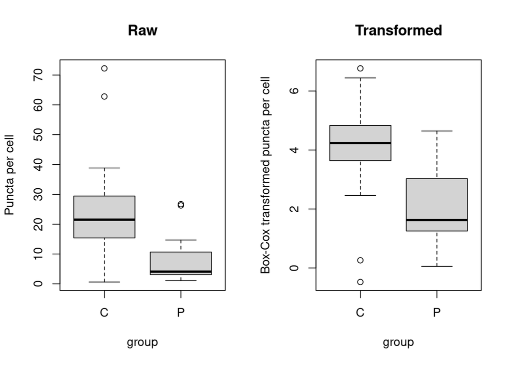

```r
par(mfrow=c(1,2))
boxplot(punctaRaw$Parietal.cortex~group, main="Raw", ylab="Puncta per cell")
boxplot(puncta$Parietal.cortex~group, main="Transformed", ylab="Box-Cox transformed puncta per cell")
```

### Insular.cortex

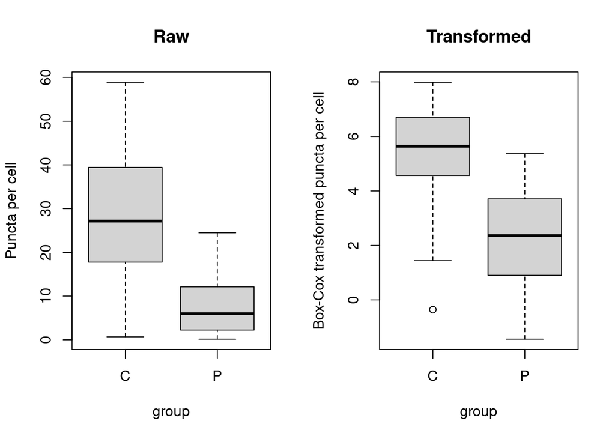

```r
par(mfrow=c(1,2))
boxplot(punctaRaw$Insular.cortex~group, main="Raw", ylab="Puncta per cell")
boxplot(puncta$Insular.cortex~group, main="Transformed", ylab="Box-Cox transformed puncta per cell")
```

### BG.Putamen

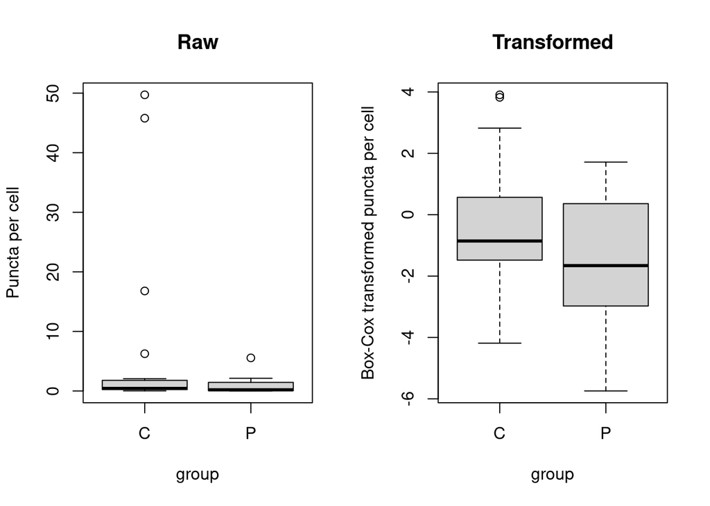

```r
par(mfrow=c(1,2))
boxplot(punctaRaw$BG.Putamen~group, main="Raw", ylab="Puncta per cell")
boxplot(puncta$BG.Putamen~group, main="Transformed", ylab="Box-Cox transformed puncta per cell")
```

### BG.Globus.P

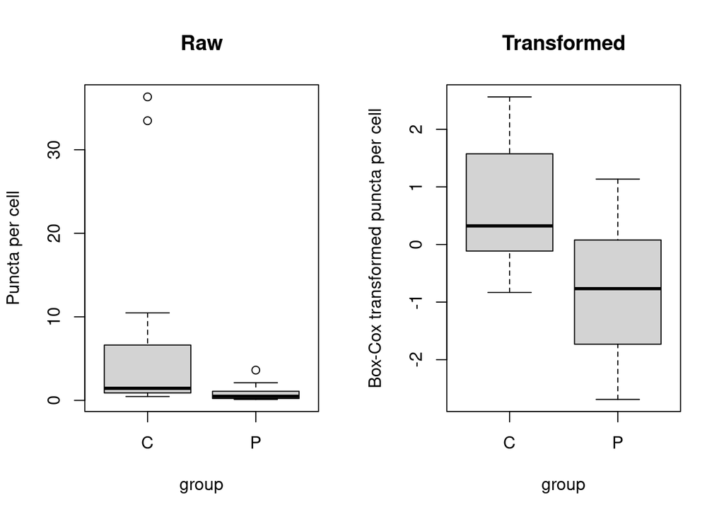

```r
par(mfrow=c(1,2))
boxplot(punctaRaw$BG.Globus.P~group, main="Raw", ylab="Puncta per cell")
boxplot(puncta$BG.Globus.P~group, main="Transformed", ylab="Box-Cox transformed puncta per cell")
```

### BG.Caudate

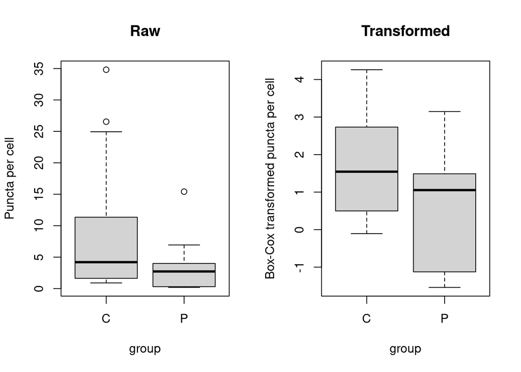

```r
par(mfrow=c(1,2))
boxplot(punctaRaw$BG.Caudate~group, main="Raw", ylab="Puncta per cell")
boxplot(puncta$BG.Caudate~group, main="Transformed", ylab="Box-Cox transformed puncta per cell")
```

### Midbrain.SN

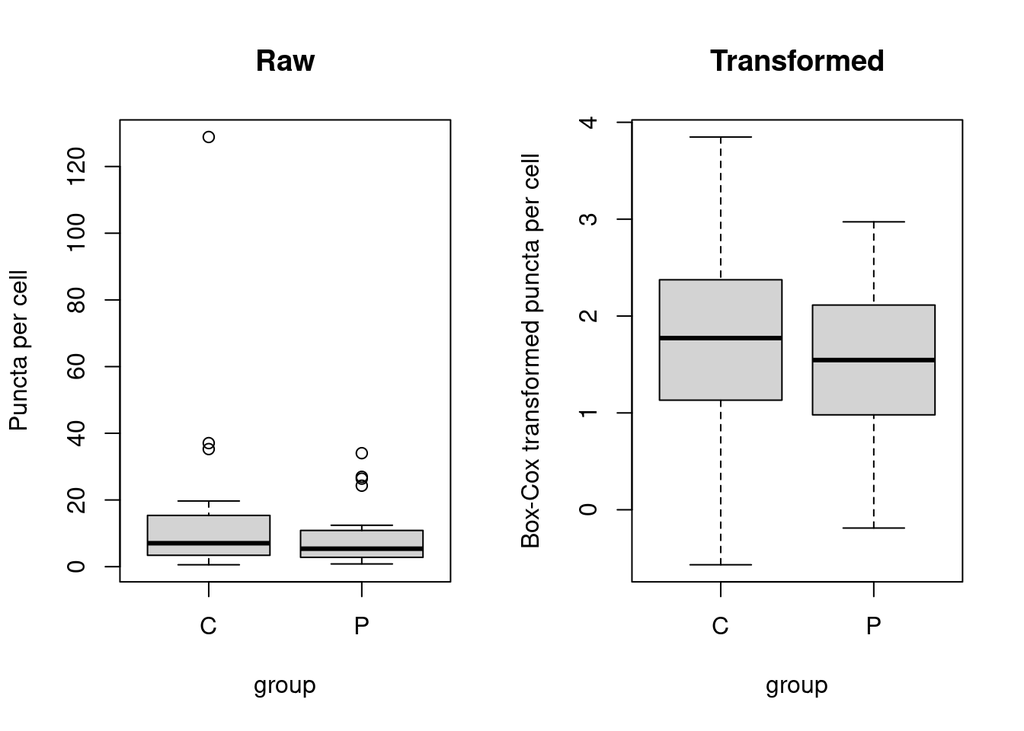

```r
par(mfrow=c(1,2))
boxplot(punctaRaw$Midbrain.SN~group, main="Raw", ylab="Puncta per cell")
boxplot(puncta$Midbrain.SN~group, main="Transformed", ylab="Box-Cox transformed puncta per cell")
```

```r
par(mfrow=c(1,1))
```

# Importance of the other variables in the best linear models

## Models with additional variables

- Insular.cortex group+batch
- BG.Putamen group+batch+Age+Gender
- BG.Globus.P group+batch+Age
- BG.Caudate group+Age+Gender

## Insular.cortex group+batch

*Model 3 in list of best models.*

Repeat ANOVA:

```r
anovaTable <- Anova(bestModels[[3]]$bestModel, type="II")
```

**Raw p-value for batch:**

```r
anovaTable$`Pr(>F)`[row.names(anovaTable)=="batch"]
```

```
## [1] 0.01630925
```

**Effect size $\epsilon^2$ of batch:**

```r
es <- epsilon_squared(anovaTable)
(es <- es$Epsilon2_partial[es$Parameter=="batch"])
```

```
## [1] 0.2217754
```

**Qualitative interpretation of effect size of batch:**

```r
interpret_epsilon_squared(es)
```

```
## [1] "large"
## (Rules: field2013)
```

**Boxplot batch**

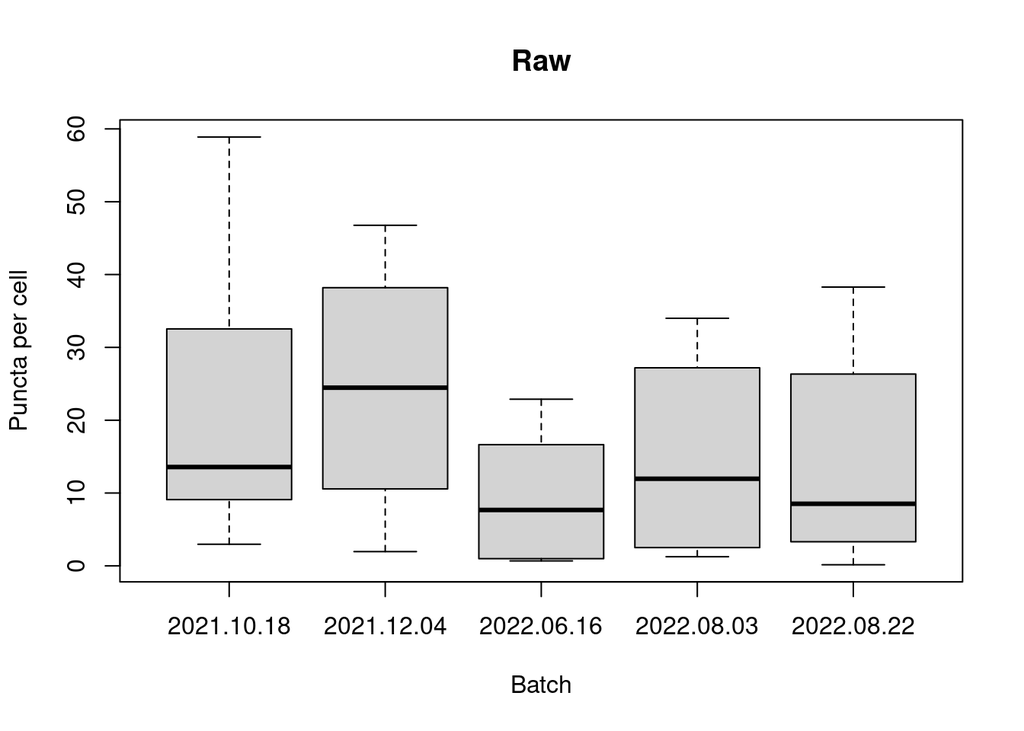

```r
boxplot(punctaRaw$Insular.cortex~batches$Insular.cortex, main="Raw", xlab="Batch", ylab="Puncta per cell")
```

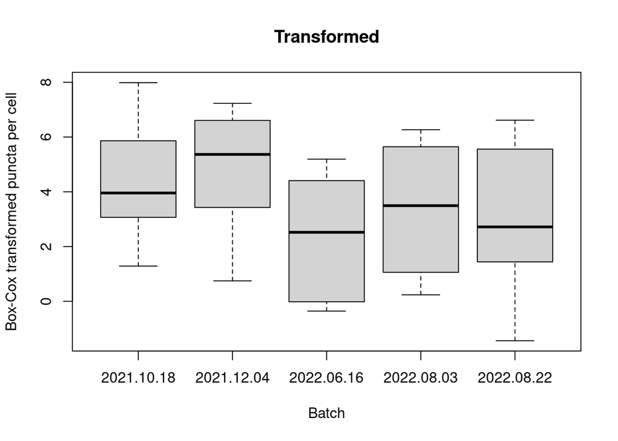

```r
boxplot(puncta$Insular.cortex~batches$Insular.cortex, main="Transformed", xlab="Batch", ylab="Box-Cox transformed puncta per cell")
```

## BG.Putamen group+batch+Age+Gender

*Model 4 in list of best models.*

Repeat ANOVA:

```r
anovaTable <- Anova(bestModels[[4]]$bestModel, type="II")
```

**Raw p-value for batch:**

```r
anovaTable$`Pr(>F)`[row.names(anovaTable)=="batch"]
```

```
## [1] 0.00232423
```

**Effect size $\epsilon^2$ of batch:**

```r
es <- epsilon_squared(anovaTable)
(es <- es$Epsilon2_partial[es$Parameter=="batch"])
```

```
## [1] 0.3283036
```

**Qualitative interpretation of effect size of batch:**

```r
interpret_epsilon_squared(es)
```

```
## [1] "large"
## (Rules: field2013)
```

**Boxplot batch**

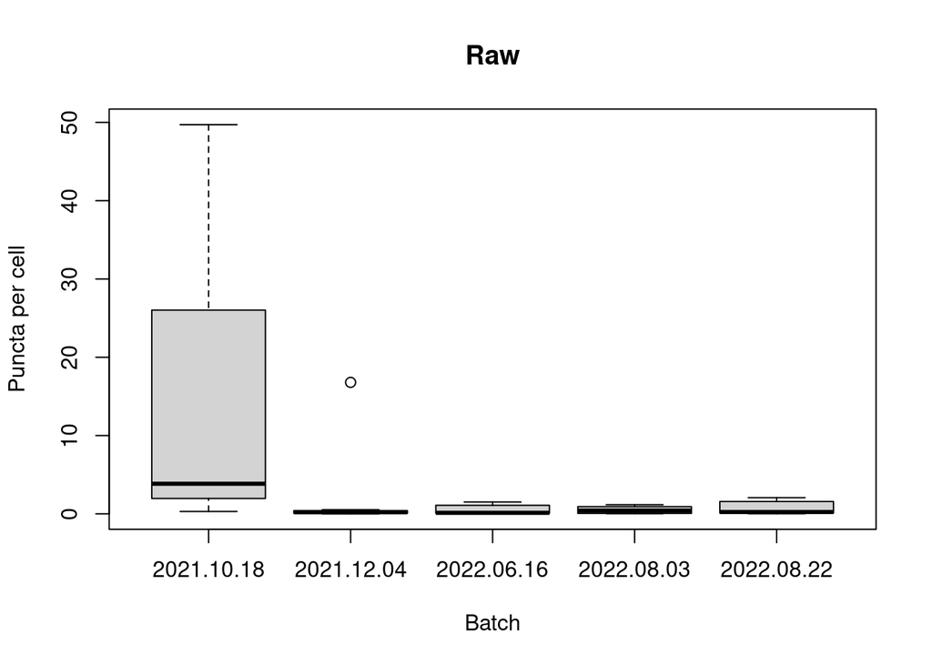

```r
boxplot(punctaRaw$BG.Putamen~batches$BG.Putamen, main="Raw", xlab="Batch", ylab="Puncta per cell")
```

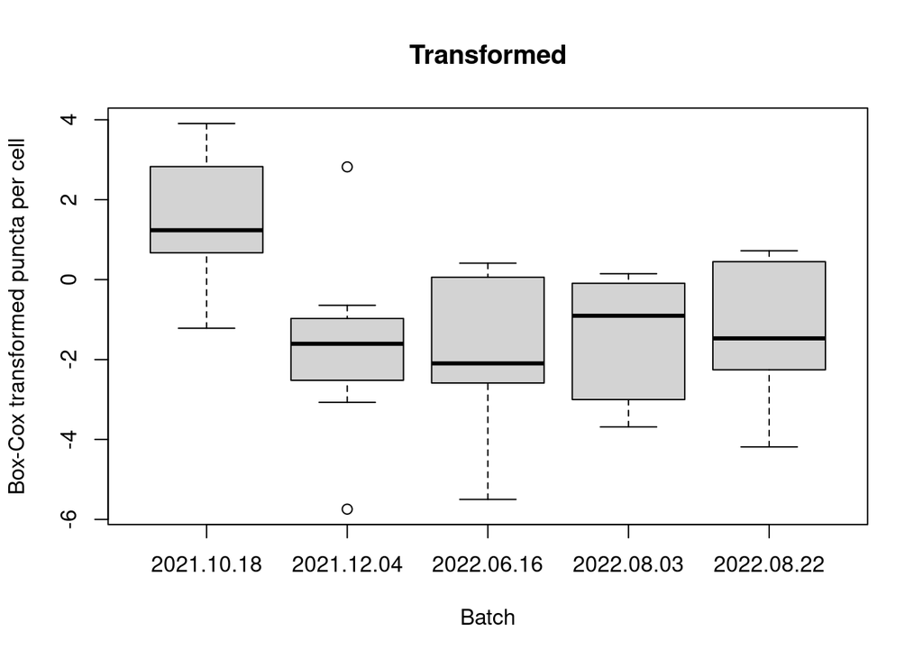

```r
boxplot(puncta$BG.Putamen~batches$BG.Putamen, main="Transformed", xlab="Batch", ylab="Box-Cox transformed puncta per cell")
```

**Raw p-value for age:**

```r
anovaTable$`Pr(>F)`[row.names(anovaTable)=="Age"]
```

```
## [1] 0.07555358
```

**Effect size $\epsilon^2$ of age:**

```r
es <- epsilon_squared(anovaTable)
(es <- es$Epsilon2_partial[es$Parameter=="Age"])
```

```
## [1] 0.06925064
```

**Qualitative interpretation of effect size of age:**

```r
interpret_epsilon_squared(es)
```

```
## [1] "medium"
## (Rules: field2013)
```

**Scatterplot Age**

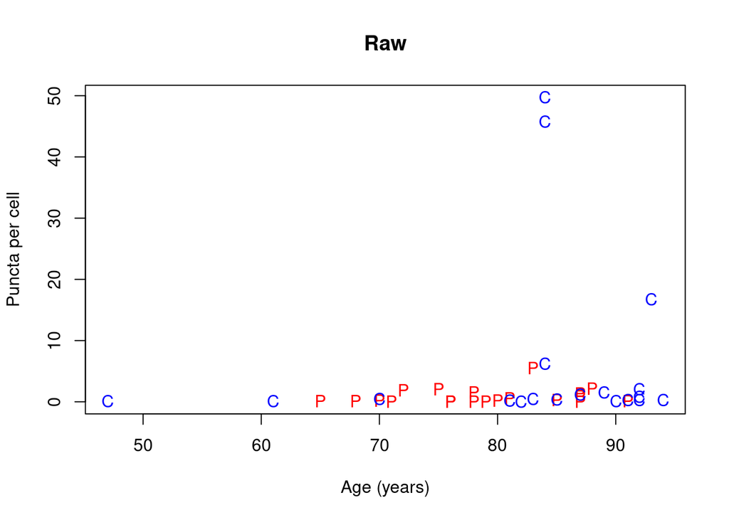

```r
plot(dat$Age, punctaRaw$BG.Putamen, pch=group, col=groupColor, main="Raw", xlab="Age (years)", ylab="Puncta per cell")
```

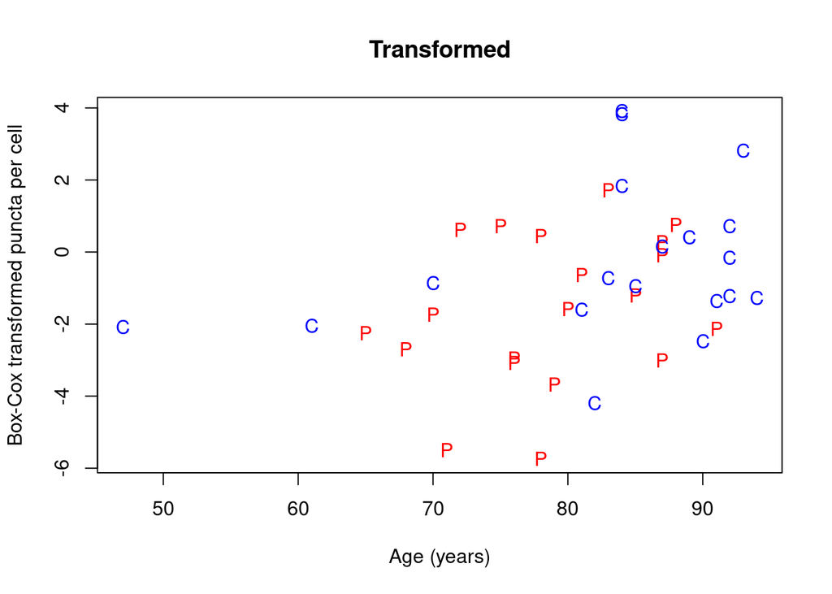

```r
plot(dat$Age, puncta$BG.Putamen, pch=group, col=groupColor, main="Transformed", xlab="Age (years)", ylab="Box-Cox transformed puncta per cell")
```

**Raw p-value for gender:**

```r
anovaTable$`Pr(>F)`[row.names(anovaTable)=="Gender"]
```

```
## [1] 0.06960025
```

**Effect size $\epsilon^2$ of gender:**

```r
es <- epsilon_squared(anovaTable)
(es <- es$Epsilon2_partial[es$Parameter=="Gender"])
```

```
## [1] 0.0733406
```

**Qualitative interpretation of effect size of gender:**

```r
interpret_epsilon_squared(es)
```

```
## [1] "medium"
## (Rules: field2013)
```

**Boxplot gender**

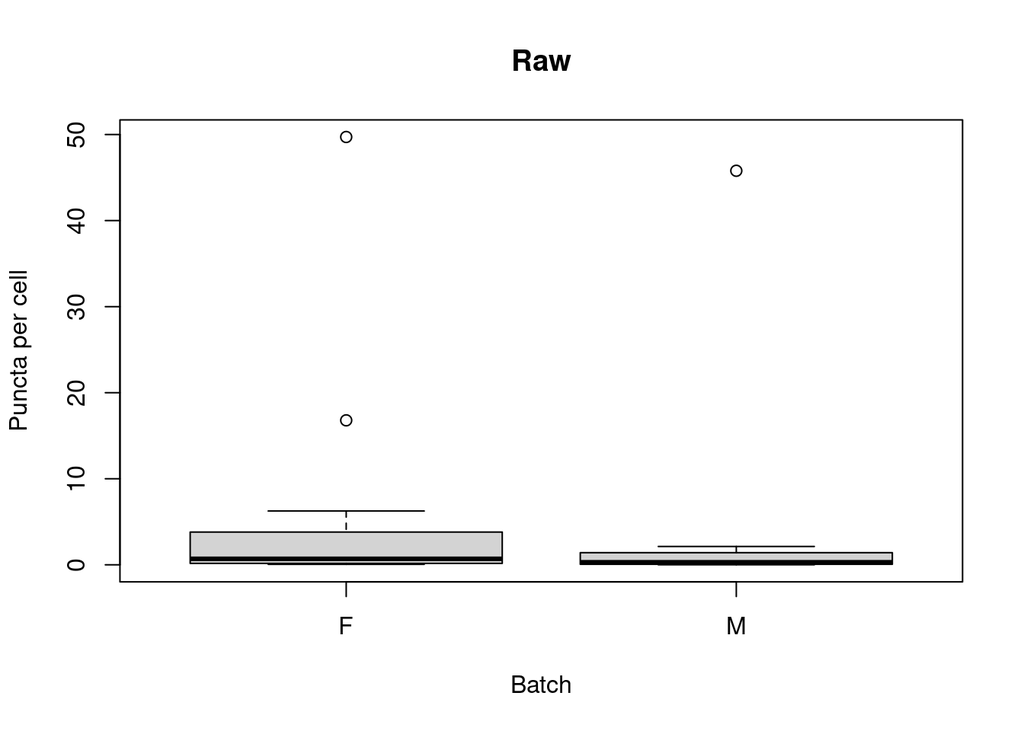

```r
boxplot(punctaRaw$BG.Putamen~dat$Gender, main="Raw", xlab="Batch", ylab="Puncta per cell")
```

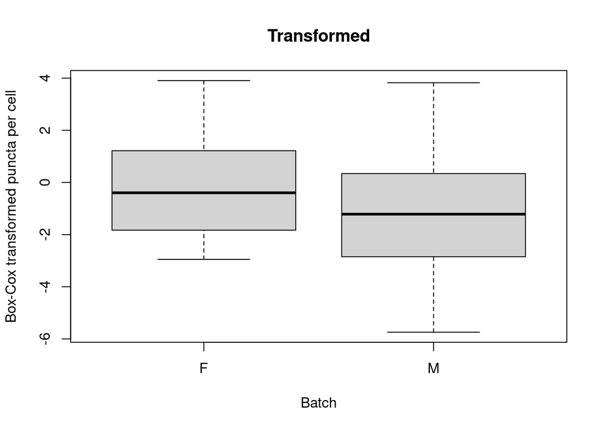

```r
boxplot(puncta$BG.Putamen~dat$Gender, main="Transformed", xlab="Batch", ylab="Box-Cox transformed puncta per cell")
```

## BG.Globus.P group+batch+Age

*Model 5 in list of best models.*

Repeat ANOVA:

```r
anovaTable <- Anova(bestModels[[5]]$bestModel, type="II")
```

**Raw p-value for batch:**

```r
anovaTable$`Pr(>F)`[row.names(anovaTable)=="batch"]
```

```
## [1] 0.005912641
```

**Effect size $\epsilon^2$ of batch:**

```r
es <- epsilon_squared(anovaTable)
(es <- es$Epsilon2_partial[es$Parameter=="batch"])
```

```
## [1] 0.3472767
```

**Qualitative interpretation of effect size of batch:**

```r
interpret_epsilon_squared(es)
```

```
## [1] "large"
## (Rules: field2013)
```

**Boxplot batch**

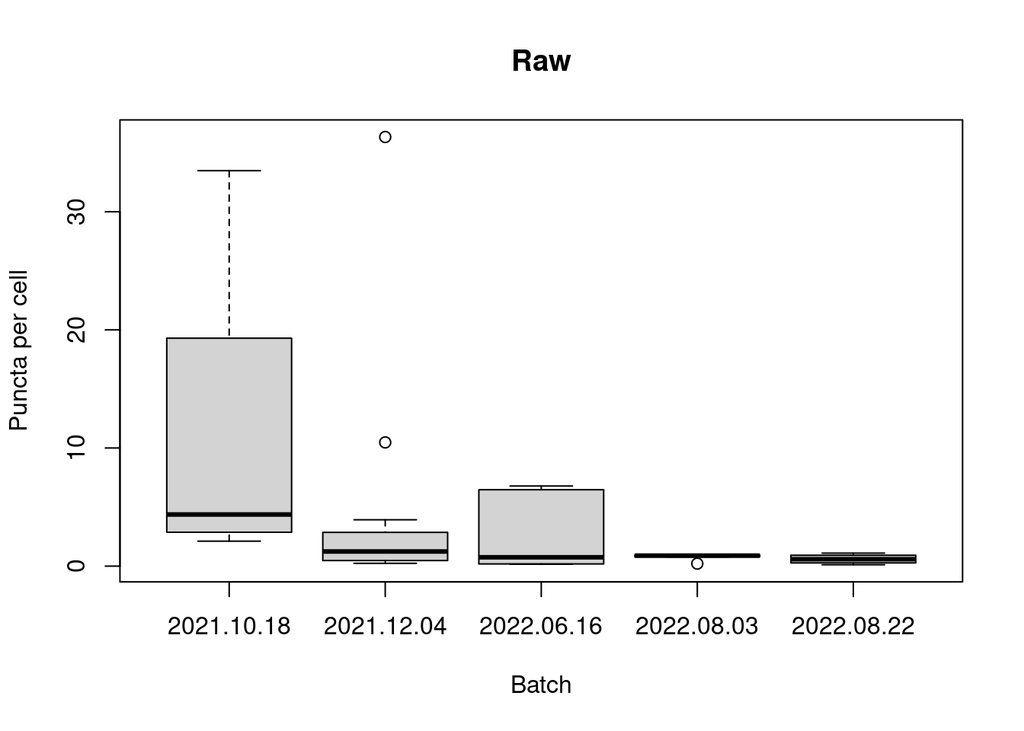

```r
boxplot(punctaRaw$BG.Globus.P~batches$BG.Globus.P, main="Raw", xlab="Batch", ylab="Puncta per cell")
```

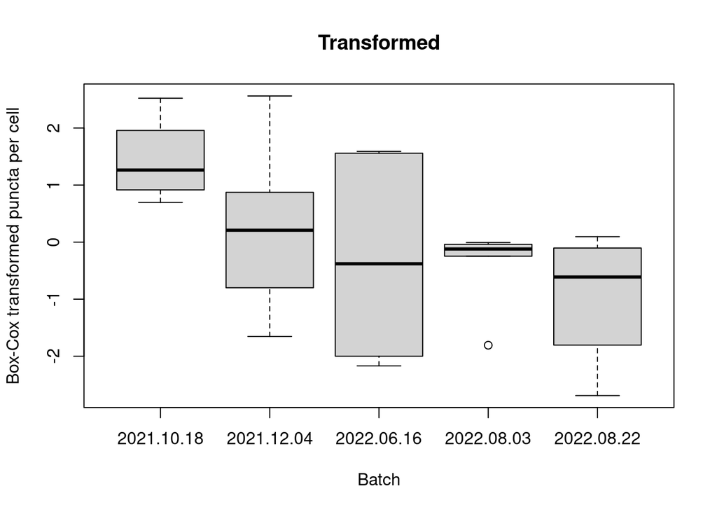

```r
boxplot(puncta$BG.Globus.P~batches$BG.Globus.P, main="Transformed", xlab="Batch", ylab="Box-Cox transformed puncta per cell")
```

**Raw p-value for age:**

```r
anovaTable$`Pr(>F)`[row.names(anovaTable)=="Age"]
```

```
## [1] 0.06379394
```

**Effect size $\epsilon^2$ of age:**

```r
es <- epsilon_squared(anovaTable)
(es <- es$Epsilon2_partial[es$Parameter=="Age"])
```

```
## [1] 0.0999595
```

**Qualitative interpretation of effect size of age:**

```r
interpret_epsilon_squared(es)
```

```
## [1] "medium"
## (Rules: field2013)
```

**Scatterplot Age**

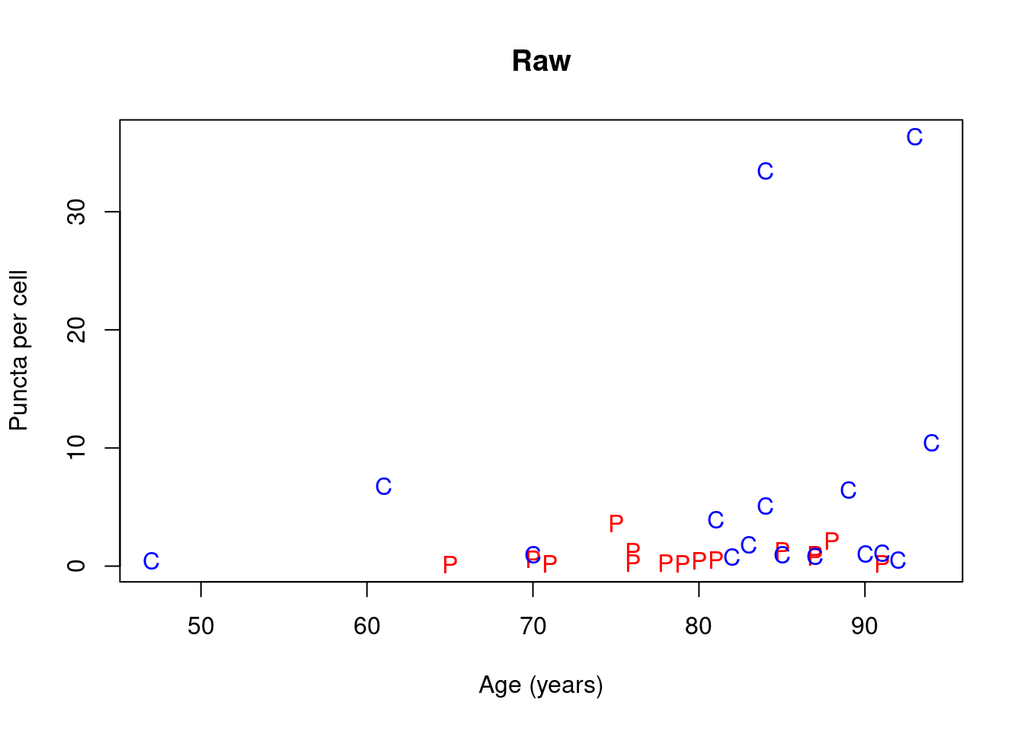

```r
plot(dat$Age, punctaRaw$BG.Globus.P, pch=group, col=groupColor, main="Raw", xlab="Age (years)", ylab="Puncta per cell")
```

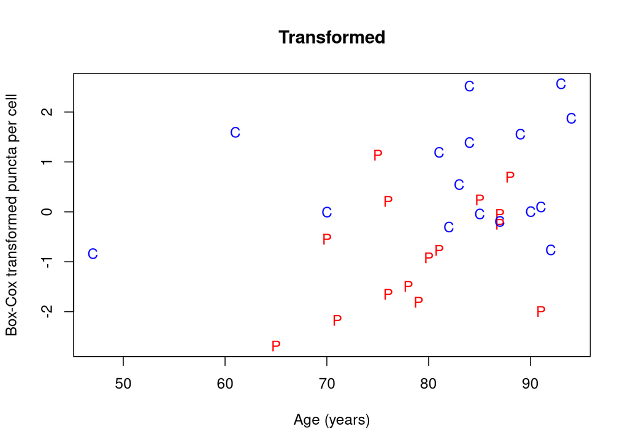

```r
plot(dat$Age, puncta$BG.Globus.P, pch=group, col=groupColor, main="Transformed", xlab="Age (years)", ylab="Box-Cox transformed puncta per cell")
```

## BG.Caudate group+Age+Gender

*Model 6 in list of best models.*

Repeat ANOVA:

```r
anovaTable <- Anova(bestModels[[6]]$bestModel, type="II")
```

**Raw p-value for age:**

```r
anovaTable$`Pr(>F)`[row.names(anovaTable)=="Age"]
```

```
## [1] 0.01383172
```

**Effect size $\epsilon^2$ of age:**

```r
es <- epsilon_squared(anovaTable)
(es <- es$Epsilon2_partial[es$Parameter=="Age"])
```

```
## [1] 0.1877528
```

**Qualitative interpretation of effect size of age:**

```r
interpret_epsilon_squared(es)
```

```
## [1] "large"
## (Rules: field2013)
```

**Scatterplot Age**

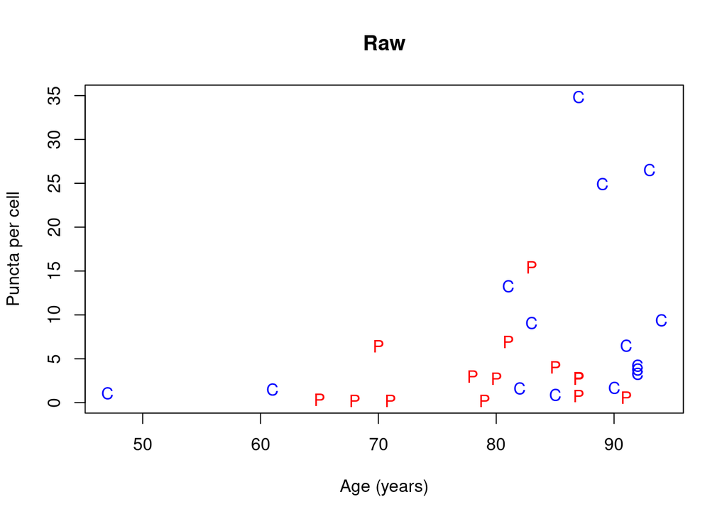

```r
plot(dat$Age, punctaRaw$BG.Caudate, pch=group, col=groupColor, main="Raw", xlab="Age (years)", ylab="Puncta per cell")
```

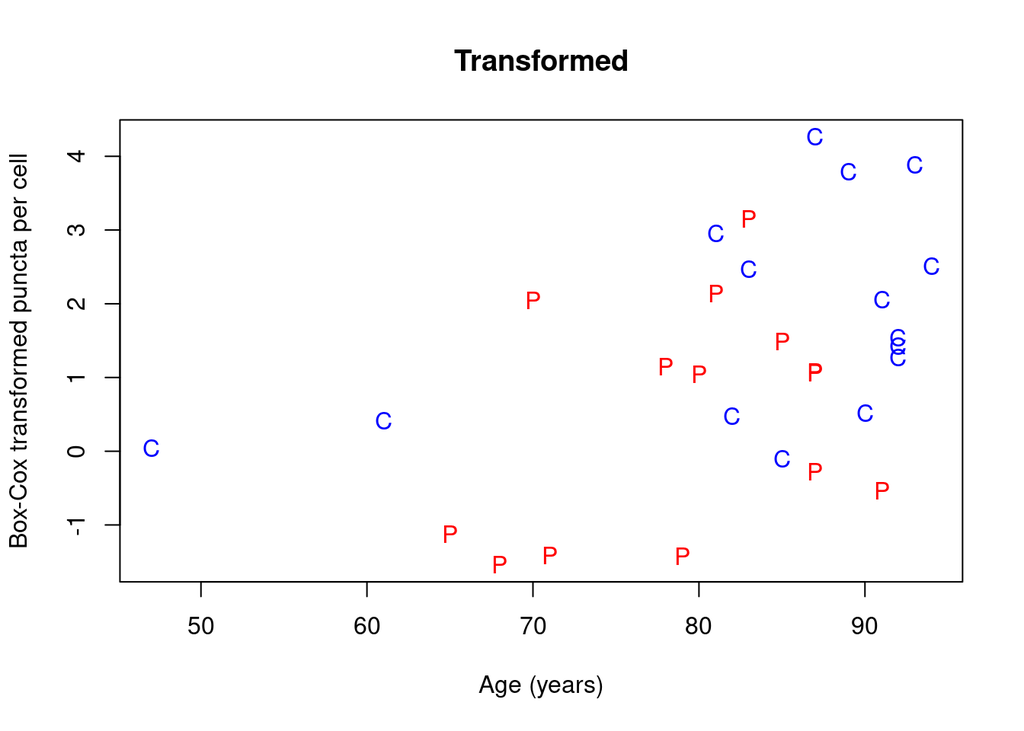

```r
plot(dat$Age, puncta$BG.Caudate, pch=group, col=groupColor, main="Transformed", xlab="Age (years)", ylab="Box-Cox transformed puncta per cell")
```

**Raw p-value for gender:**

```r
anovaTable$`Pr(>F)`[row.names(anovaTable)=="Gender"]
```

```
## [1] 0.05083182
```

**Effect size $\epsilon^2$ of gender:**

```r
es <- epsilon_squared(anovaTable)
(es <- es$Epsilon2_partial[es$Parameter=="Gender"])
```

```
## [1] 0.1098554
```

**Qualitative interpretation of effect size of gender:**

```r
interpret_epsilon_squared(es)
```

```
## [1] "medium"
## (Rules: field2013)
```

**Boxplot gender**

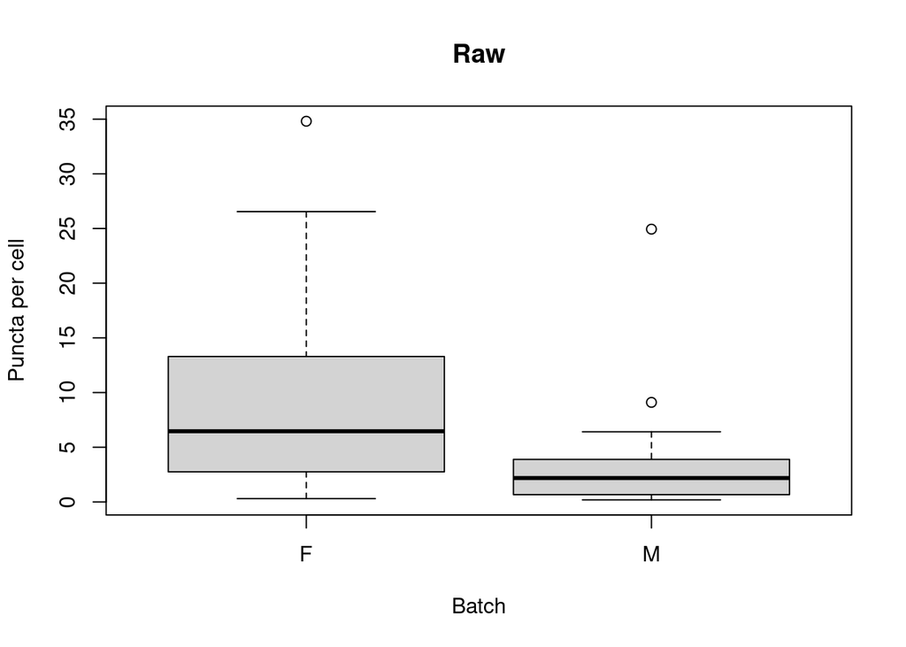

```r
boxplot(punctaRaw$BG.Caudate~dat$Gender, main="Raw", xlab="Batch", ylab="Puncta per cell")
```

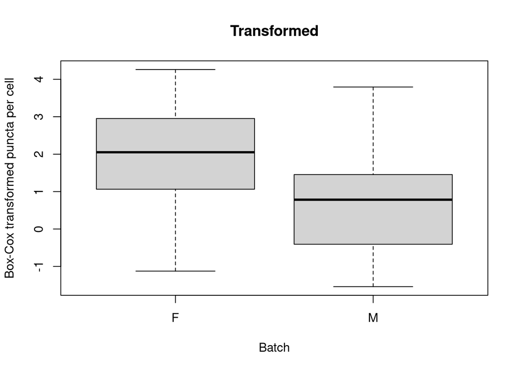

```r
boxplot(puncta$BG.Caudate~dat$Gender, main="Transformed", xlab="Batch", ylab="Box-Cox transformed puncta per cell")
```

# References

```r
citation()
```

```
##
##   R Core Team (2023). _R: A Language and Environment for Statistical
##   Computing_. R Foundation for Statistical Computing, Vienna, Austria.
##   <https://www.R-project.org/>.
##
## A BibTeX entry for LaTeX users is
##
##   @Manual{,
##     title = {R: A Language and Environment for Statistical Computing},
##     author = {{R Core Team}},
##     organization = {R Foundation for Statistical Computing},
##     address = {Vienna, Austria},
##     year = {2023},
##     url = {https://www.R-project.org/},
##   }
##
## We have invested a lot of time and effort in creating R, please cite it
## when using it for data analysis. See also 'citation("pkgname")' for
## citing R packages.
```

```r
citation("stringr")
```

```
##
##   Wickham H (2023). _stringr: Simple, Consistent Wrappers for Common
##   String Operations_. R package version 1.5.1,
##   <https://CRAN.R-project.org/package=stringr>.
##
## A BibTeX entry for LaTeX users is
##
##   @Manual{,
##     title = {stringr: Simple, Consistent Wrappers for Common String Operations},
##     author = {Hadley Wickham},
##     year = {2023},
##     note = {R package version 1.5.1},
##     url = {https://CRAN.R-project.org/package=stringr},
##   }
```

```r
citation("MASS")
```

```
##
##   Venables, W. N. & Ripley, B. D. (2002) Modern Applied Statistics with
##   S. Fourth Edition. Springer, New York. ISBN 0-387-95457-0
##
## A BibTeX entry for LaTeX users is
##
##   @Book{,
##     title = {Modern Applied Statistics with S},
##     author = {W. N. Venables and B. D. Ripley},
##     publisher = {Springer},
##     edition = {Fourth},
##     address = {New York},
##     year = {2002},
##     note = {ISBN 0-387-95457-0},
##     url = {https://www.stats.ox.ac.uk/pub/MASS4/},
##   }
```

```r
citation("car")
```

```
##
##   Fox J, Weisberg S (2019). _An R Companion to Applied Regression_,
##   Third edition. Sage, Thousand Oaks CA.
##   <https://socialsciences.mcmaster.ca/jfox/Books/Companion/>.
##
## A BibTeX entry for LaTeX users is
##
##   @Book{,
##     title = {An {R} Companion to Applied Regression},
##     edition = {Third},
##     author = {John Fox and Sanford Weisberg},
##     year = {2019},
##     publisher = {Sage},
##     address = {Thousand Oaks {CA}},
##     url = {https://socialsciences.mcmaster.ca/jfox/Books/Companion/},
##   }
```

```r
citation("AICcmodavg")
```

```
##
##   Mazerolle MJ (2023). _AICcmodavg: Model selection and multimodel
##   inference based on (Q)AIC(c)_. R package version 2.3.3,
##   <https://cran.r-project.org/package=AICcmodavg>.
##
## A BibTeX entry for LaTeX users is
##
##   @Manual{AICcmodavg-package,
##     title = {AICcmodavg: Model selection and multimodel inference based on (Q)AIC(c)},
##     author = {Marc J. Mazerolle},
##     year = {2023},
##     note = {R package version 2.3.3},
##     url = {https://cran.r-project.org/package=AICcmodavg},
##     bibtex = {TRUE},
##   }
```

```r
citation("effectsize")
```

```
##
##   Ben-Shachar M, Lüdecke D, Makowski D (2020). effectsize: Estimation
##   of Effect Size Indices and Standardized Parameters. Journal of Open
##   Source Software, 5(56), 2815. doi: 10.21105/joss.02815
##
## A BibTeX entry for LaTeX users is
##
##   @Article{,
##     title = {{e}ffectsize: Estimation of Effect Size Indices and Standardized Parameters},
##     author = {Mattan S. Ben-Shachar and Daniel Lüdecke and Dominique Makowski},
##     year = {2020},
##     journal = {Journal of Open Source Software},
##     volume = {5},
##     number = {56},
##     pages = {2815},
##     publisher = {The Open Journal},
##     doi = {10.21105/joss.02815},
##     url = {https://doi.org/10.21105/joss.02815},
##   }
```

Field, A (2013) Discovering statistics using IBM SPSS Statistics. Fourth Edition. Sage:London.